# Reproducible Research: Project 1: Steps

Samantha Neeno

December 5, 2016

PA1_template.Rmd

## Loading and preprocessing the data

1. Load the data (i.e. read.csv())

```r
require(RCurl)
download.file("https://github.com/rdpeng/RepData_PeerAssessment1/blob/master/activity.zip", destfile="activity.zip", mode="wb")
unzip(zipfile = 'activity.zip')
activityData <- read.csv('activity.csv')
                            head(activityData)
```

```
##   steps       date interval
## 1    NA 2012-10-01        0
## 2    NA 2012-10-01        5
## 3    NA 2012-10-01       10
## 4    NA 2012-10-01       15
## 5    NA 2012-10-01       20
## 6    NA 2012-10-01       25
```

2. Process/transform the data (if necessary) into a format suitable for your analysis

```r
# Convert the factor "date" to an actual date
activityData$dateLabel<-as.Date(activityData$date)
#activityData$totalInterval<-as.Date(activityData$date)

#sapply(activityData$steps ~ dateLabel, function(x) sum(is.na(x)))
```

## What is mean total number of steps taken per day?

*For this part of the assignment, you can ignore the missing values in the dataset.*

1. Calculate the total number of steps taken per day

```r
activityDateSum<-aggregate.data.frame(activityData$steps,by=list(activityData$dateLabel),FUN=sum)
```

2. If you do not understand the difference between a histogram and a barplot, research the difference between them. Make a histogram of the total number of steps taken each day

[figure not shown]

```r
hist(activityDateSum$x,xlab="Number of Steps Taken",ylab="Percent Total",main ="Total Steps per Day")
```

3. Calculate and report the mean and median of the total number of steps taken per day

```r
mean(activityDateSum$x,na.rm = TRUE)
```

```
## [1] 10766.19
```

```r
median(activityDateSum$x,na.rm = TRUE)
```

```
## [1] 10765
```

## What is the average daily activity pattern?

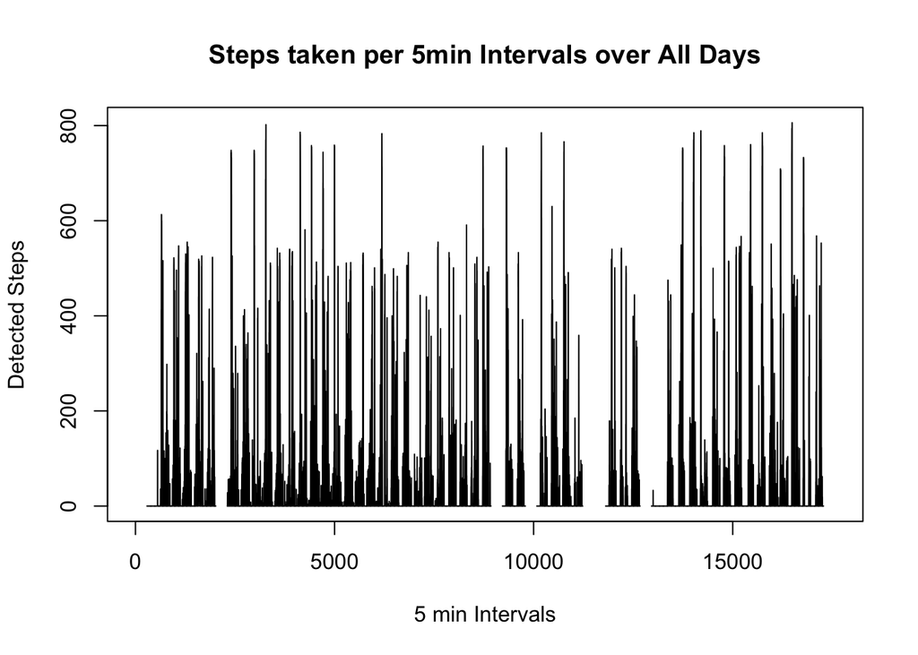

```r
plot(activityData$steps,type ="l",xlab="5 min Intervals",ylab="Detected Steps",main = "Steps taken per 5min Intervals over All Days")
```

```r
max(activityData$steps,na.rm=TRUE)
```

```
## [1] 806
```

## Imputing missing values

*Note that there are a number of days/intervals where there are missing values (coded as NA). The presence of missing days may introduce bias into some calculations or summaries of the data.*

1. Calculate and report the total number of missing values in the dataset (i.e. the total number of rows with NAs)

```r
sum(is.na(activityData$steps))
```

```
## [1] 2304
```

2. Devise a strategy for filling in all of the missing values in the dataset. The strategy does not need to be sophisticated. For example, you could use the mean/median for that day, or the mean for that 5-minute interval, etc.

If all the values for a given day are NA, then I will set all of the step values to zero. If there are NA values interspersed within a day of recording, they will be replaced with the mean number of steps taken that day.

3. Create a new dataset that is equal to the original dataset but with the missing data filled in.

```r
actDateMean<-aggregate(activityData$steps, by=list(dateLabel=activityData$dateLabel), FUN=mean, rm.na = FALSE)

rmNAactivityData <- activityData

for(i in 1:nrow(activityData)) {
    if(is.na(actDateMean$x[activityData$dateLabel[i]]) && is.na(activityData$steps[i])) rmNAactivityData$steps[i] <- 0
    if(!is.na(actDateMean$x[activityData$dateLabel[i]]) && is.na(activityData$steps[i])) rmNAactivityData$steps[i] == actDateMean$x[which(actDateMean$dateLabel == activityData$dateLabel[i])]
}
```

4. Make a histogram of the total number of steps taken each day and Calculate and report the mean and median total number of steps taken per day. Do these values differ from the estimates from the first part of the assignment? What is the impact of imputing missing data on the estimates of the total daily number of steps?

[figure not shown]

```r
rmNAactivityDateSum<-aggregate.data.frame(activityData$steps,by=list(activityData$dateLabel),FUN=sum)
rmNAactDateMean<-aggregate(rmNAactivityData$steps, by=list(dateLabel=rmNAactivityData$dateLabel), FUN=mean, rm.na = FALSE)
hist(rmNAactivityDateSum$x,xlab="Number of Steps Taken",ylab="Percent Total",main="Total Steps per Day, Cleaned Data")
```

```r
sum(is.na(rmNAactivityData$steps))
```

```
## [1] 0
```

```r
mean(rmNAactivityDateSum$x,na.rm = TRUE)
```

```
## [1] 10766.19
```

```r
median(rmNAactivityDateSum$x,na.rm = TRUE)
```

```
## [1] 10765
```

## Are there differences in activity patterns between weekdays and weekends?

*For this part the weekdays() function may be of some help here. Use the dataset with the filled-in missing values for this part.*

1. Create a new factor variable in the dataset with two levels – “weekday” and “weekend” indicating whether a given date is a weekday or weekend day.

```r
weekDayType <- function(date) {
     if (weekdays(date) %in% c("Saturday", "Sunday")) {
          "weekend"
     } else {
          "weekday"
     }
}

rmNAactivityData$dayType <- as.factor(sapply(rmNAactivityData$dateLabel, weekDayType))
rmNAactDateMean$dayType <- as.factor(sapply(rmNAactDateMean$dateLabel, weekDayType))

str(rmNAactivityData)
```

```
## 'data.frame':    17568 obs. of  5 variables:
##  $ steps    : num  0 0 0 0 0 0 0 0 0 0 ...
##  $ date     : Factor w/ 61 levels "2012-10-01","2012-10-02",..: 1 1 1 1 1 1 1 1 1 1 ...
##  $ interval : int  0 5 10 15 20 25 30 35 40 45 ...
##  $ dateLabel: Date, format: "2012-10-01" "2012-10-01" ...
##  $ dayType  : Factor w/ 2 levels "weekday","weekend": 1 1 1 1 1 1 1 1 1 1 ...
```

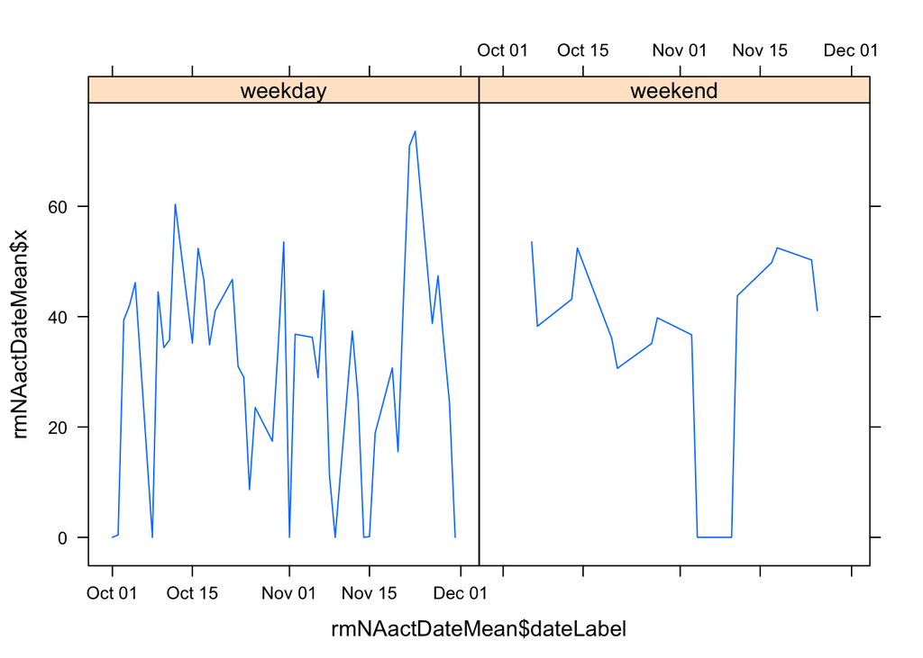

```r
library(lattice)
xyplot(rmNAactDateMean$x ~ rmNAactDateMean$dateLabel| factor(dayType), data = rmNAactDateMean, type = "l")
```